# 教学文档 3：COMET 核心结局集 Delphi 全流程

Ming Yang

2026-10-10

# 1. COS 要解决的问题

核心结局集（Core Outcome Set, COS）回答：

> 某一健康状况的临床试验，**至少**应该测量哪些结局？

它不是诊疗共识，也不是适宜性评价。COMET Handbook 广泛使用 9 分制：

- 1–3：有限重要性
- 4–6：重要但非关键
- 7–9：关键结局

以及 **70/15 规则**（须预先写进方案）：

- **Consensus in：** ≥70% 评 7–9，且 <15% 评 1–3
- **Consensus out：** ≥70% 评 1–3，且 <15% 评 7–9
- 其余：**No consensus**

```r
library(delphir)
data("cos_demo", package = "delphir")
cos_demo
```

```
#> Delphi 研究
#>   题目: IgA 肾病临床试验核心结局集（模拟 COMET Delphi）
#>   场景: COMET 核心结局集
#>   专家: 80 人；条目: 25；轮次: 1, 2
#>   评分行数: 3850
```

```r
table(cos_demo$panel$stakeholder)
```

```
#>
#>   医生   患者 研究者
#>     40     25     15
```

# 2. 为什么阈值和临床共识不同

临床专家共识常用 75%–80% + Median + IQR 的**复合标准**，因为要决定“写不写进共识条款”。

COS 的 70/15 同时管“关键”和“明确不重要”，并防止少数强烈反对被平均掉。一条结局 76% 评 7–9 但 18% 评 1–3，按 70/15 **不能纳入**：反对虽不是主流，但已超过 15%。

```r
protocol <- preset_protocol("comet_cos")
protocol$rules[c("comet_in_high", "comet_in_low_max",
                 "comet_out_low", "comet_out_high_max")]
```

```
#> $comet_in_high
#> [1] 0.7
#>
#> $comet_in_low_max
#> [1] 0.15
#>
#> $comet_out_low
#> [1] 0.7
#>
#> $comet_out_high_max
#> [1] 0.15
```

不要把临床共识的 80% 规则或 RAM 的 DI 偷偷换到 COS 上，除非方案里写明并论证。

# 3. 范围、使用者和患者参与

```r
unlist(cos_demo$meta)
```

```
#>                                                    title
#>        "IgA 肾病临床试验核心结局集（模拟 COMET Delphi）"
#>                                                objective
#>            "确定 IgA 肾病干预试验应至少测量的核心结局。"
#>                                                    users
#>                       "临床试验申办者、研究者与患者组织"
#>                                                geography
#>                               "国际多利益相关者（模拟）"
#>                                            evidence_note
#>     "候选结局来自系统评价与患者访谈后的条目池（模拟）。"
#>                                                anonymity
#> "在线匿名评分；反馈含本人评分、总体及利益相关者组摘要。"
#>                                                   ethics
#>                                         "教学模拟数据。"
```

**解读：** ACCORD 的 M5（患者与公众参与）在 COS 中几乎是刚需。没有患者的“核心结局”很容易变成医生方便测量的实验室指标。本面板把患者当作与医生、研究者并列的利益相关者，而不是“咨询对象”。

# 4. 候选结局从哪里来

Modified Delphi 的第一轮不是开放提问，而是系统评价 + 患者访谈后的条目池。`outcome_domain` 帮助避免同一领域堆叠过多相似结局。

```r
table(cos_demo$items$outcome_domain)
```

```
#>
#>      不良事件        实验室      疾病活动     病死/生存 症状/生命质量
#>             9             4             3             3             1
#>      资源利用
#>             5
```

```r
head(cos_demo$items[, c("item_id", "item_text", "outcome_domain", "pattern")])
```

```
#>   item_id                                          item_text outcome_domain
#> 1     O01                                           全因死亡       资源利用
#> 2     O02 肾脏复合终点（血肌酐倍增/进入肾脏替代/肾源性死亡）       资源利用
#> 3     O03                               估计肾小球滤过率斜率       疾病活动
#> 4     O04                                         蛋白尿变化       不良事件
#> 5     O05                                       终末期肾脏病       不良事件
#> 6     O06                                               疲劳      病死/生存
#>   pattern
#> 1 core_in
#> 2 core_in
#> 3 core_in
#> 4 core_in
#> 5 core_in
#> 6 core_in
```

`pattern = patient_dissent` 只在模拟数据中出现，对应教学点：医生认为关键、患者不认为关键。

# 5. 参与与脱落

COS 面板通常更大，在线调查脱落更常见。必须分轮、分组报告。

```r
response_summary(cos_demo)$by_round
```

```
#>   round n_invited n_responded response_rate
#> 1     1        80          80         100.0
#> 2     2        80          74          92.5
```

```r
response_summary(cos_demo)$retention
```

```
#>   from_round to_round n_previous n_retained n_lost n_new retention_rate
#> 1          1        2         80         74      6     0           92.5
```

**解读：** 若第 2 轮丢掉的主要是患者，最终 COS 会被临床视角主导。DCAT 的 Panelist retention 要求报告流失类型，而不仅是总人数。

# 6. 总体 70/15 判定

```r
res <- analyze_delphi(cos_demo)
res
```

```
#> Delphi 分析结果
#>   场景: COMET 核心结局集
#>   题目: IgA 肾病临床试验核心结局集（模拟 COMET Delphi）
#>   轮次: 1, 2
#>   参与度:
#>     第 1 轮  80/80  (100.0%)
#>     第 2 轮  74/80  (92.5%)
#>   末轮分类:
#>     排除共识: 3
#>     未达共识: 11
#>     纳入共识: 11
#>   稳定性建议终止: 否
```

```r
last <- res$last_classification
last[, c("item_id", "item_text", "n_valid", "n_unable", "p_high", "p_low", "class_zh")]
```

```
#>    item_id                                          item_text n_valid n_unable
#> 26     O01                                           全因死亡      74        0
#> 27     O02 肾脏复合终点（血肌酐倍增/进入肾脏替代/肾源性死亡）      74        0
#> 28     O03                               估计肾小球滤过率斜率      74        0
#> 29     O04                                         蛋白尿变化      74        0
#> 30     O05                                       终末期肾脏病      74        0
#> 31     O06                                               疲劳      74        0
#> 32     O07                                   健康相关生命质量      74        0
#> 33     O08                                               水肿      74        0
#> 34     O09                                           血压控制      74        0
#> 35     O10                                       感染相关住院      74        0
#> 36     O11                                 糖皮质激素累积暴露      74        0
#> 37     O12                                   患者总体印象变化      68        6
#> 38     O13                               工作与学业受影响天数      74        0
#> 39     O14                                               血尿      72        2
```

[output cut: 37 more lines]

**逐类解读：**

- **纳入共识：** 同时满足“多数视为关键”和“很少视为不重要”。死亡、肾脏复合终点等通常落在这里。
- **排除共识：** 多数明确认为不是核心。进入 COS 会增加测量负担。
- **未达共识：** 包括中间派多、或两端都有相当比例。这些应进入共识会议，而不是用均数强行排序塞进核心集。

注意 `n_unable`：患者对某些实验室结局选“无法判断”是合理的，不能把 NA 填成 5 分。

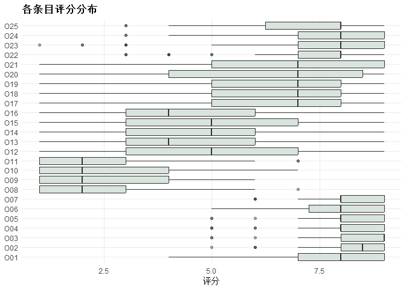

```r
plot_item_distribution(cos_demo, round = 2)
```

# 7. 本教程最重要的一张表：分层

```r
st <- res$stakeholder
# 找总体纳入但某组未纳入的结局
overall_in <- last$item_id[last$class == "consensus_in"]
st_in <- st[st$item_id %in% overall_in, c("item_id", "group_level", "n_valid",
                                         "p_high", "p_low", "class_zh")]
st_in
```

```
#>    item_id group_level n_valid    p_high     p_low class_zh
#> 1      O01        医生      35  85.71429  0.000000 纳入共识
#> 2      O02        医生      35  94.28571  0.000000 纳入共识
#> 3      O03        医生      35  97.14286  0.000000 纳入共识
#> 4      O04        医生      35  91.42857  0.000000 纳入共识
#> 5      O05        医生      35 100.00000  0.000000 纳入共识
#> 6      O06        医生      35  91.42857  0.000000 纳入共识
#> 7      O07        医生      35  94.28571  0.000000 纳入共识
#> 22     O22        医生      35  74.28571  2.857143 纳入共识
#> 23     O23        医生      35  80.00000  8.571429 纳入共识
#> 24     O24        医生      35  85.71429  0.000000 纳入共识
#> 25     O25        医生      35  62.85714  5.714286 未达共识
#> 26     O01        患者      24  95.83333  0.000000 纳入共识
#> 27     O02        患者      24  95.83333  0.000000 纳入共识
#> 28     O03        患者      24  95.83333  0.000000 纳入共识
```

[output cut: 19 more lines]

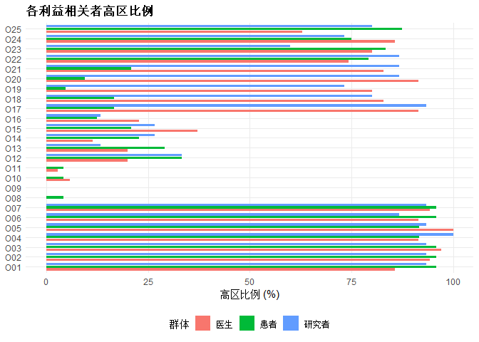

```r
plot_stakeholder(res)
```

**方法学解读（请停在这里看）：**

假设某结局总体 74% 评 7–9，医生 92%、方法学 88%、患者 42%。只报总体会写成“接近共识/已共识”，但患者明确不认可。COMET 认为这种条目**不能假装已经形成核心结局**。

正确做法：

1. 分列各组 P(7–9) 与 P(1–3)；
2. 在共识会议上专门讨论组间相反的条目；
3. 可能的结果包括：纳入但必须同时测量患者报告结局、改定义、或保持 no consensus。

这就是文档强调的 stakeholder-stratified analysis。

# 8. 与临床共识规则并排，看会不会判错

```r
clinical_rule <- classify_consensus(res$item_summary, preset_protocol("clinical_consensus"))
cmp <- merge(
  last[, c("item_id", "p_high", "p_low", "class_zh")],
  clinical_rule[clinical_rule$round == res$last_round,
                c("item_id", "class_zh")],
  by = "item_id", suffixes = c("_COMET", "_临床复合")
)
head(cmp, 10)
```

```
#>    item_id    p_high    p_low class_zh_COMET class_zh_临床复合
#> 1      O01 90.540541  0.00000       纳入共识          高度共识
#> 2      O02 94.594595  0.00000       纳入共识          高度共识
#> 3      O03 95.945946  0.00000       纳入共识          高度共识
#> 4      O04 93.243243  0.00000       纳入共识          高度共识
#> 5      O05 95.945946  0.00000       纳入共识          高度共识
#> 6      O06 91.891892  0.00000       纳入共识          高度共识
#> 7      O07 94.594595  0.00000       纳入共识          高度共识
#> 8      O08  1.351351 82.43243       排除共识          倾向排除
#> 9      O09  0.000000 64.86486       未达共识          未达共识
#> 10     O10  4.054054 71.62162       排除共识          未达共识
```

**解读：** 同一组数字，规则不同结论就不同。这不是软件 bug，而是**研究目的决定规则**。写论文时必须报告你预先选择的是 70/15 还是复合标准。

# 9. 稳定性：刚过 70% 不一定能停

```r
res$stability[, c("item_id", "p_high_r1", "p_high_r2", "class_r1", "class_r2",
                  "class_unchanged")]
```

```
#>    item_id p_high_r1 p_high_r2      class_r1      class_r2 class_unchanged
#> 1      O01  85.00000 90.540541  consensus_in  consensus_in            TRUE
#> 2      O02  87.50000 94.594595  consensus_in  consensus_in            TRUE
#> 3      O03  85.00000 95.945946  consensus_in  consensus_in            TRUE
#> 4      O04  88.75000 93.243243  consensus_in  consensus_in            TRUE
#> 5      O05  85.00000 95.945946  consensus_in  consensus_in            TRUE
#> 6      O06  85.00000 91.891892  consensus_in  consensus_in            TRUE
#> 7      O07  85.00000 94.594595  consensus_in  consensus_in            TRUE
#> 8      O08   8.75000  1.351351  no_consensus consensus_out           FALSE
#> 9      O09  10.00000  0.000000 consensus_out  no_consensus           FALSE
#> 10     O10   3.75000  4.054054 consensus_out consensus_out            TRUE
#> 11     O11   2.50000  2.702703 consensus_out consensus_out            TRUE
#> 12     O12  25.00000 26.470588  no_consensus  no_consensus            TRUE
#> 13     O13  30.00000 21.621622  no_consensus  no_consensus            TRUE
#> 14     O14  25.31646 18.055556  no_consensus  no_consensus            TRUE
#> 15     O15  28.75000 29.729730  no_consensus  no_consensus            TRUE
#> 16     O16  25.00000 17.567568  no_consensus  no_consensus            TRUE
#> 17     O17  52.50000 67.567568  no_consensus  no_consensus            TRUE
#> 18     O18  52.50000 60.810811  no_consensus  no_consensus            TRUE
#> 19     O19  61.53846 56.338028  no_consensus  no_consensus            TRUE
#> 20     O20  60.81081 66.197183  no_consensus  no_consensus            TRUE
#> 21     O21  56.25000 63.513514  no_consensus  no_consensus            TRUE
#> 22     O22  47.50000 78.378378  no_consensus  consensus_in           FALSE
#> 23     O23  46.25000 77.027027  no_consensus  consensus_in           FALSE
#> 24     O24  35.00000 79.729730  no_consensus  consensus_in           FALSE
#> 25     O25  43.75000 74.324324  no_consensus  consensus_in           FALSE
```

```r
res$stopping
```

```
#> $recommend_stop
#> [1] FALSE
#>
#> $class_unchanged_pct
#> [1] 0.76
#>
#> $median_stable_pct
#> [1] 0.84
#>
#> $p_high_stable_pct
#> [1] 0.72
#>
#> $max_rounds
#> [1] 3
#>
#> $current_round
#> [1] 2
#>
#> $note
#> [1] "Wilcoxon P>0.05 不能单独定义为意见稳定，因为 P 值依赖样本量。"
```

**解读：** 第 1 轮 60%、第 2 轮 76%、若还有第 3 轮冲到 90%，说明意见仍在变。COS 同样适用“稳定性 + 共识”双条件。未稳定的纳入会在后续试验中难以复现。

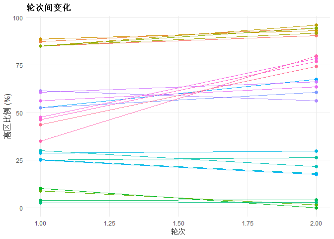

```r
plot_round_shift(res, metric = "p_high")
```

# 10. 脱落是否改变结局排序

```r
db <- res$dropout
head(db[order(db$wilcoxon_p), c("item_id", "median_completer", "median_dropout",
                                "p_high_completer", "p_high_dropout", "wilcoxon_p")])
```

```
#>    item_id median_completer median_dropout p_high_completer p_high_dropout
#> 5      O05              8.0            9.0         83.78378      100.00000
#> 12     O12              5.0            6.0         24.28571       33.33333
#> 2      O02              8.0            8.5         86.48649      100.00000
#> 6      O06              8.0            7.5         83.78378      100.00000
#> 18     O18              6.5            7.5         50.00000       83.33333
#> 21     O21              7.0            7.5         55.40541       66.66667
#>    wilcoxon_p
#> 5   0.1621593
#> 12  0.2634166
#> 2   0.3435886
#> 6   0.3870505
#> 18  0.4112576
#> 21  0.4187421
```

若脱落者对“疲劳”“生命质量”评分更低，而留下的人把它们抬进核心集，COS 对患者的代表性就成问题。即使 Wilcoxon 不显著，也要描述人数和方向，不要只写 P 值。

# 11. 反馈给多利益相关者

COMET 实践通常反馈：本人评分 + 总体 + **各利益相关者组**摘要。

```r
fb <- prepare_feedback(res, round = 1)
fb[fb$expert_id == fb$expert_id[1],
   c("item_id", "own_score", "p_high", "class_zh")]
```

```
#>    item_id own_score   p_high class_zh
#> 1      O01         8 85.00000 纳入共识
#> 2      O02         9 87.50000 纳入共识
#> 3      O03         7 85.00000 纳入共识
#> 4      O04         5 88.75000 纳入共识
#> 5      O05         5 85.00000 纳入共识
#> 6      O06         7 85.00000 纳入共识
#> 7      O07         9 85.00000 纳入共识
#> 8      O08         3  8.75000 未达共识
#> 9      O09         1 10.00000 排除共识
#> 10     O10         2  3.75000 排除共识
#> 11     O11         1  2.50000 排除共识
#> 12     O12         4 25.00000 未达共识
#> 13     O13         6 30.00000 未达共识
#> 14     O14         3 25.31646 未达共识
#> 15     O15         6 28.75000 未达共识
#> 16     O16         3 25.00000 未达共识
#> 17     O17         9 52.50000 未达共识
#> 18     O18         8 52.50000 未达共识
#> 19     O19         9 61.53846 未达共识
#> 20     O20         9 60.81081 未达共识
#> 21     O21         9 56.25000 未达共识
#> 22     O22         7 47.50000 未达共识
#> 23     O23         8 46.25000 未达共识
#> 24     O24         7 35.00000 未达共识
#> 25     O25         7 43.75000 未达共识
```

第二轮只对未达共识或新改写的结局重评，是常见设计；但至少要保证同一结局有两轮可比数据，否则无法谈稳定性。

# 12. 意见主题

```r
summarize_comments(study = cos_demo)$by_theme
```

```
#>            theme  n
#> 4     应分层报告 38
#> 2       定义不清 27
#> 5     测量负担高 26
#> 1       不是核心 23
#> 3 对患者至关重要 20
```

“测量负担高”“定义不清”往往比再投一轮更有用：先改操作定义或更换测量工具，再评分。

# 13. 共识会议与最终 COS

会议不应推翻已稳定的 Consensus in / out。重点：

- 总体与患者组冲突；
- 临界（例如 68% vs 72%）；
- 同一领域多个结局如何合并。

最终文件建议同时给出：

- 核心结局列表（必须测）；
- 推荐但非核心；
- 明确排除；
- 仍无共识者。

```r
table(last$class_zh)
```

```
#>
#> 排除共识 未达共识 纳入共识
#>        3       11       11
```

# 14. 报告与核对清单

```r
html <- delphi_report(res, file = tempfile(fileext = ".html"), template = "comet_cos")
file.exists(html)
```

```
#> [1] TRUE
```

COS 报告除 ACCORD 外，还应对照 COMET 数据库的登记信息。DCAT 核心四项在在线 COS Delphi 中同样适用：匿名投票、至少两轮、统计汇总、个性化反馈。

```r
dcat_checklist(res)[, c("id", "core", "status", "item")]
```

```
#>        id  core status
#> 1   DCAT1  TRUE    Yes
#> 2   DCAT2  TRUE    Yes
#> 3   DCAT3  TRUE    Yes
#> 4   DCAT4  TRUE    Yes
#> 5   DCAT5 FALSE    Yes
#> 6   DCAT6 FALSE    Yes
#> 7   DCAT7 FALSE    Yes
#> 8   DCAT8 FALSE    Yes
#> 9   DCAT9 FALSE    Yes
#> 10 DCAT10 FALSE    Yes
#> 11 DCAT11 FALSE Unsure
#> 12 DCAT12 FALSE    Yes
#> 13 DCAT13 FALSE Unsure
#> 14 DCAT14 FALSE    Yes
```

[output cut: 19 more lines]

# 15. 本场景常见错误

1. 只用总体百分比，掩盖患者组反对；
2. 把 70/15 的“15%”丢掉，只看是否 ≥70%；
3. 用临床共识的 Median+IQR 复合标准却声称遵循 COMET；
4. 患者人数过少还做分层结论；
5. 把实验室指标的“无法判断”填成中间值；
6. 会议用少数专家替换全体 Delphi；
7. 不报告各组脱落；
8. 把 Kendall W 显著当成“可以宣布核心结局集”。

# 16. 换成自己的 COS 数据

```r
study <- delphi_study(
  preset_protocol("comet_cos"),
  panel = your_panel,          # 必须含 stakeholder
  items = your_outcomes,       # 建议含 outcome_domain
  ratings = your_ratings,
  comments = your_comments,
  meta = list(
    title = "……核心结局集",
    objective = "确定试验至少应测量的结局",
    users = "申办者、研究者、患者组织",
    geography = "国际"
  )
)
analyze_delphi(study) |> delphi_report(file = "cos-report.html")
```

另外两套教程：

- `vignette("clinical-consensus", package = "delphir")`
- `vignette("rand-ucla", package = "delphir")`

可用 `delphi_guides()` 查看安装后的全部教学入口。